# Machine Learning Hackaton

Rapport

DARRIGOL Tristan - BERTHET Ulysse

# Analyse

## Librairies

Commencons dans un premier temps pas décrire et détailler les différentes librairies utilisées :

```r
library(caret)
library(caTools)
library(doParallel)
library(mlbench)
cl <- makePSOCKcluster(5)
registerDoParallel(cl)
```

### caTools

Librairie de manipulation de data, et d’outils statisiques utilisée a de multiples reprises au cours des TD.

### caret

Une des librairies de Machine Learning les plus complètes disponible sur R, elle contient de nombreux modèles, méthodes de préprocessing, de manipulation de données et de test. Cette librairie hautement personnalisable permet en plus de toute ces fonctionnalités, cette librairie, jointe à doParallel, permet d’entrainer en parallèle plusieurs modèles (multiprocessing).

[Documentation caret](https://topepo.github.io/caret/index.html)

### doParallel

Librairie permettant l’utilisation séparée de plusieurs coeurs sur la meme machine, ici, 5 coeurs.

### mlbench

Librairie nous permettant de choisir nos modèles en les comparants via la metrics “F1” telle que demandée lors du challenge, en lieu et place d’Accuracy ou Kappa, proposées par caret.

## Data

Passons maintenant à la description des données. Il faut dans un premier temps charger le dataset :

```r
data <- read.csv("data.csv")
```

Puis commencons par regarder les premières lignes pour avoir une idée de la forme des données :

```r
head(data, 3)
```

```
##   age         job marital           education default housing loan   contact
## 1  60 blue-collar married            basic.9y unknown      no   no telephone
## 2  43  management married professional.course      no     yes   no telephone
## 3  42 blue-collar married            basic.9y      no     yes   no telephone
##   month day_of_week duration campaign pdays previous    poutcome emp.var.rate
## 1   may         mon      301        1   999        0 nonexistent          1.1
## 2   may         mon      134        1   999        0 nonexistent          1.1
## 3   jun         wed      264        2   999        0 nonexistent          1.4
##   cons.price.idx cons.conf.idx euribor3m nr.employed  y
## 1         93.994         -36.4     4.857      5191.0 no
## 2         93.994         -36.4     4.857      5191.0 no
## 3         94.465         -41.8     4.864      5228.1 no
```

```r
colnames(data)
```

```
##  [1] "age"            "job"            "marital"        "education"
##  [5] "default"        "housing"        "loan"           "contact"
##  [9] "month"          "day_of_week"    "duration"       "campaign"
## [13] "pdays"          "previous"       "poutcome"       "emp.var.rate"
## [17] "cons.price.idx" "cons.conf.idx"  "euribor3m"      "nr.employed"
## [21] "y"
```

De cela, nous tirons deux chose :

Il nous faut transformer les variables qualitatives en facteurs de manière à pouvoir appliquer une variété plus large d’algorithmes.  
Le choix d’algorthme instinctif est donc la Random Forest, assez peu sensible aux variations de ses paramètres et se comportant bien sur des data set de hautes dimension, encore plus lorsqu’ils comportent une portion importante de variables qualitatives.

### Transformation en facteurs

Nous avons pour cela créé une fonction nous permettant de transformer le dataset ou tout subset extrait de ce dernier :

```r
preProcessing=function(data){
  data$job=as.factor(data$job)
  data$marital=as.factor(data$marital)
  data$education=as.factor(data$education)
  data$default=as.factor(data$default)
  data$housing=as.factor(data$housing)
  data$loan=as.factor(data$loan)
  data$contact=as.factor(data$contact)
  data$day_of_week=as.factor(data$day_of_week)
  data$poutcome=as.factor(data$poutcome)
  data
}
data <- data[-c(11)]
data <- preProcessing(data)
data$y=as.factor(data$y)
```

### Scaling and centering

De plus, nous avons de nomreuses valeures numériques d’échelles très variables, il semble donc nécessaire de scale et center les données, pour cela nous utiliserons la fonction “preProcess” du package caret, cependant certains algorithmes, comme les ensembles d’arbes de décisions, n’y sont pas sensible, nous disposons donc maintenant de deux set, un scale et center et l’autre non.

```r
preProcValues = preProcess(data, method = c("center", "scale"))
training_set.scaled = predict(preProcValues, data)
```

### Spliting the data

Pour nos deux data sets, il est necessaire de split en train set et test set:

```r
split = sample.split(data$y, SplitRatio = 0.75)
training_set = subset(data, split == TRUE)
test_set = subset(data, split == FALSE)

split = sample.split(data$y, SplitRatio = 0.75)
training_set_scaled = subset(data, split == TRUE)
test_set_scaled = subset(training_set.scaled, split == FALSE)
```

# Models

Maintenant que nos données sont prêtes à être utilisées, passons donc à la conception et l’entrainement des modèles :

Les modèles les plus performants dans le cadre de notre problème de classification ont de très fortes chances d’etre, des randoms forests, des GBM, ou bien des SVM.[1] Cependant, le temps necessaire à l’entrainement des SVM étant très élevé, nous ecartons donc cette méthode pour le moment, car nous voulons effectuer du tuning de paramètres via une grid search et des cross-validations.

De manière à pouvoir effectuer les cross validations, nous allons réutiliser la ligne de commande suivante tout au long du challenge :

```r
trainctrl <- trainControl(verboseIter = TRUE,method = "cv",number = 5,summaryFunction = prSummary,classProbs = TRUE)

metric = "F"
```

## Random Forest

Assez peu sensible au paramétrage, nous performons tout de même à une cross validation, sur 3 valeurs possible pour mtry (nombre de predicteurs sélectionnés aléatoirement)

```r
grid.forest1=expand.grid(mtry=c(4,10,40))
set.seed(1)
fit.forest1<- train(y~.,
                 data=training_set,
                 method="rf",
                 metric=metric,
                 trControl = trainctrl,
                 tuneGrid=grid.forest1)
print(fit.forest1)
```

```
## Random Forest
##
## 14696 samples
##    19 predictor
##     2 classes: 'no', 'yes'
##
## No pre-processing
## Resampling: Cross-Validated (5 fold)
## Summary of sample sizes: 11757, 11757, 11757, 11756, 11757
## Resampling results across tuning parameters:
##
##   mtry  AUC        Precision  Recall     F
##    4    0.8452662  0.9087532  0.9835269  0.9446594
##   10    0.9181783  0.9141900  0.9759063  0.9440375
##   40    0.9112217  0.9156271  0.9673620  0.9407819
##
## F was used to select the optimal model using the largest value.
## The final value used for the model was mtry = 4.
```

```r
print(confusionMatrix(test_set$y,predict(fit.forest1,test_set),mode = "prec_recall")
)
```

```
## Confusion Matrix and Statistics
##
##           Reference
## Prediction   no  yes
##        no  4262   68
##        yes  450  118
##
##                Accuracy : 0.8942
##                  95% CI : (0.8853, 0.9027)
##     No Information Rate : 0.962
##     P-Value [Acc > NIR] : 1
##
##                   Kappa : 0.2713
##
##  Mcnemar's Test P-Value : <2e-16
##
##               Precision : 0.9843
##                  Recall : 0.9045
##                      F1 : 0.9427
##              Prevalence : 0.9620
##          Detection Rate : 0.8702
##    Detection Prevalence : 0.8840
##       Balanced Accuracy : 0.7695
##
##        'Positive' Class : no
##
```

```r
grid.forest2=expand.grid(mtry=c(1,3,5))
set.seed(1)
fit.forest2<- train(y~.,
                 data=training_set,
                 method="rf",
                 metric=metric,
                 trControl = trainctrl,
                 tuneGrid=grid.forest2)
print(fit.forest2)
```

```
## Random Forest
##
## 14696 samples
##    19 predictor
##     2 classes: 'no', 'yes'
##
## No pre-processing
## Resampling: Cross-Validated (5 fold)
## Summary of sample sizes: 11757, 11757, 11757, 11756, 11757
## Resampling results across tuning parameters:
##
##   mtry  AUC        Precision  Recall     F
##   1     0.1931332  0.8841627  1.0000000  0.9385205
##   3     0.7403675  0.9059407  0.9866830  0.9445845
##   5     0.8832662  0.9103870  0.9821414  0.9449010
##
## F was used to select the optimal model using the largest value.
## The final value used for the model was mtry = 5.
```

```r
print(confusionMatrix(test_set$y,predict(fit.forest2,test_set),mode = "prec_recall")
)
```

```
## Confusion Matrix and Statistics
##
##           Reference
## Prediction   no  yes
##        no  4245   85
##        yes  446  122
##
##                Accuracy : 0.8916
##                  95% CI : (0.8825, 0.9002)
##     No Information Rate : 0.9577
##     P-Value [Acc > NIR] : 1
##
##                   Kappa : 0.2696
##
##  Mcnemar's Test P-Value : <2e-16
##
##               Precision : 0.9804
##                  Recall : 0.9049
##                      F1 : 0.9411
##              Prevalence : 0.9577
##          Detection Rate : 0.8667
##    Detection Prevalence : 0.8840
##       Balanced Accuracy : 0.7471
##
##        'Positive' Class : no
##
```

Nous avons donc soumis les prévisions données par ce modèle sur Kaggle.

Malheureusement pour nous, nous avions sous-estimé la taille du dataset et le temps que prendrait le training ainsi que la cross-validation. Nous avions donc lancé plusieurs modèles que nous n’avons pas eu le temps de tester, ces modèles étaient un classique GMB, ou “Gradient Boosting Machine”, et un, plus récent, le XGB, ou “Extreme Gradient Boosting”. Pour ce faire nous avons donc utilisé les méthodes suivantes :

## XGB

```r
set.seed(1)
xgbGrid <- expand.grid(nrounds = c(100,200,500),
                       max_depth = c(3, 10, 15, 20),
                       colsample_bytree = seq(0.5, 0.9, length.out = 3),
                       ## valeurs par défaut :
                       eta = 0.1,
                       gamma = 0,
                       min_child_weight = 1,
                       subsample = 1)
fit.Xboost<- train(y~.,
                  data=training_set,
                  method="xgbTree",
                  metric=metric,
                  trControl = trainctrl,
                  tuneGrid=xgbGrid)
```

```
## Fitting nrounds = 100, max_depth = 3, eta = 0.1, gamma = 0, colsample_bytree = 0.7, min_child_weight = 1, subsample = 1 on full training set
```

```r
print(fit.Xboost)
```

```
## eXtreme Gradient Boosting
##
## 14696 samples
##    19 predictor
##     2 classes: 'no', 'yes'
##
## No pre-processing
## Resampling: Cross-Validated (5 fold)
## Summary of sample sizes: 11757, 11757, 11757, 11756, 11757
## Resampling results across tuning parameters:
##
##   max_depth  colsample_bytree  nrounds  AUC        Precision  Recall
##    3         0.5               100      0.9577523  0.9077209  0.9850666
##    3         0.5               200      0.9572680  0.9096697  0.9821415
##    3         0.5               500      0.9561279  0.9107215  0.9792164
##    3         0.7               100      0.9577763  0.9085298  0.9846817
##    3         0.7               200      0.9567989  0.9096758  0.9822185
##    3         0.7               500      0.9562933  0.9113468  0.9780618
##    3         0.9               100      0.9574846  0.9083387  0.9847586
##    3         0.9               200      0.9569749  0.9095765  0.9817566
##    3         0.9               500      0.9558723  0.9111129  0.9776000
##   10         0.5               100      0.9525917  0.9138907  0.9746750
##   10         0.5               200      0.9504557  0.9140744  0.9736743
##   10         0.5               500      0.9449137  0.9158558  0.9685169
##   10         0.7               100      0.9528313  0.9135746  0.9748287
##   10         0.7               200      0.9501995  0.9142507  0.9717497
##   10         0.7               500      0.9448704  0.9164363  0.9674389
##   10         0.9               100      0.9521239  0.9138298  0.9739049
##   10         0.9               200      0.9492553  0.9146178  0.9713648
##   10         0.9               500      0.9446085  0.9154166  0.9663615
##   15         0.5               100      0.9505120  0.9142227  0.9730581
##   15         0.5               200      0.9470853  0.9157306  0.9703642
##   15         0.5               500      0.9443015  0.9159102  0.9642060
##   15         0.7               100      0.9488209  0.9144805  0.9705182
##   15         0.7               200      0.9465610  0.9152278  0.9690556
##   15         0.7               500      0.9438519  0.9154511  0.9635133
##   15         0.9               100      0.9497850  0.9143429  0.9704410
##   15         0.9               200      0.9464769  0.9149460  0.9672081
##   15         0.9               500      0.9441286  0.9154402  0.9625125
##   20         0.5               100      0.9492167  0.9132355  0.9722886
```

[output cut: 40 more lines]

```
##   0.9396681
##   0.9388686
##   0.9410891
##   0.9395616
##   0.9384850
##
## Tuning parameter 'eta' was held constant at a value of 0.1
## Tuning
##  parameter 'min_child_weight' was held constant at a value of 1
##
## Tuning parameter 'subsample' was held constant at a value of 1
## F was used to select the optimal model using the largest value.
## The final values used for the model were nrounds = 100, max_depth = 3, eta
##  = 0.1, gamma = 0, colsample_bytree = 0.7, min_child_weight = 1 and subsample
##  = 1.
```

```r
print(confusionMatrix(test_set$y,predict(fit.Xboost,test_set),mode = "prec_recall")
)
```

```
## Confusion Matrix and Statistics
##
##           Reference
## Prediction   no  yes
##        no  4272   58
##        yes  448  120
##
##                Accuracy : 0.8967
##                  95% CI : (0.8878, 0.9051)
##     No Information Rate : 0.9637
##     P-Value [Acc > NIR] : 1
##
##                   Kappa : 0.282
##
##  Mcnemar's Test P-Value : <2e-16
##
##               Precision : 0.9866
##                  Recall : 0.9051
##                      F1 : 0.9441
##              Prevalence : 0.9637
##          Detection Rate : 0.8722
##    Detection Prevalence : 0.8840
##       Balanced Accuracy : 0.7896
##
##        'Positive' Class : no
##
```

nrounds : Nombre d’itération de boosting à effectuer, plus cette valeur est grande plus l’algorithme est long à s’entrainer.  
max_depth : Profondeur d’arbre maximale, Risque d’overfitting (ou d’underfitting) si cette valeur est trop grande (ou trop petite respectivement).  
colsample_bytree : Pourcentage des colonnes utilisée pour construire un arbre.

*valeurs par défaut*  
eta : Learning Rate lors de la descente de gradient  
gamma : Minimum de la fonction objectif pour partitionner une feuille.  
min_child_weight : Somme des poids minimum jusqu’a la feuille pour continuer à partitionner.  
subsample : Ration d’echantillonage des instance d’entrainement. Si a 0.5, le XGB va echantilloner la moitié du dataset avant de créer les arbres

## GBM

```r
set.seed(1)
gbmGrid <- expand.grid(n.trees = c(1000,2000,3000),
                       interaction.depth = c(2, 5, 15),
                       ## valeurs fixée  :
                       shrinkage = 0.01,
                       n.minobsinnode = 1)
fit.Gboost1<- train(y~.,
                  data=training_set,
                  method="gbm",
                  metric=metric,
                  trControl = trainctrl,
                  tuneGrid=gbmGrid)
print(fit.Gboost1)
```

```
## Stochastic Gradient Boosting
##
## 14696 samples
##    19 predictor
##     2 classes: 'no', 'yes'
##
## No pre-processing
## Resampling: Cross-Validated (5 fold)
## Summary of sample sizes: 11757, 11757, 11757, 11756, 11757
## Resampling results across tuning parameters:
##
##   interaction.depth  n.trees  AUC        Precision  Recall     F
##    2                 1000     0.9563664  0.9069296  0.9862982  0.9449465
##    2                 2000     0.9569797  0.9086508  0.9839120  0.9447841
##    2                 3000     0.9570673  0.9094596  0.9835272  0.9450440
##    5                 1000     0.9569456  0.9099733  0.9826804  0.9449292
##    5                 2000     0.9572689  0.9107006  0.9812948  0.9446799
##    5                 3000     0.9572524  0.9115194  0.9793703  0.9442270
##   15                 1000     0.9571262  0.9117346  0.9788315  0.9440904
##   15                 2000     0.9562529  0.9124258  0.9752907  0.9428095
##   15                 3000     0.9550988  0.9134725  0.9735971  0.9425751
##
## Tuning parameter 'shrinkage' was held constant at a value of 0.01
##
## Tuning parameter 'n.minobsinnode' was held constant at a value of 1
## F was used to select the optimal model using the largest value.
## The final values used for the model were n.trees = 3000, interaction.depth =
##  2, shrinkage = 0.01 and n.minobsinnode = 1.
```

```r
print(confusionMatrix(test_set$y,predict(fit.Gboost1,test_set),mode = "prec_recall")
)
```

```
## Confusion Matrix and Statistics
##
##           Reference
## Prediction   no  yes
##        no  4267   63
##        yes  451  117
##
##                Accuracy : 0.8951
##                  95% CI : (0.8861, 0.9035)
##     No Information Rate : 0.9633
##     P-Value [Acc > NIR] : 1
##
##                   Kappa : 0.2722
##
##  Mcnemar's Test P-Value : <2e-16
##
##               Precision : 0.9855
##                  Recall : 0.9044
##                      F1 : 0.9432
##              Prevalence : 0.9633
##          Detection Rate : 0.8712
##    Detection Prevalence : 0.8840
##       Balanced Accuracy : 0.7772
##
##        'Positive' Class : no
##
```

n.trees : Similaire au nrounds du XGB (nombre d’itération)  
interaction_depth : Similaire au max_depth du XGB  
shrinkage : Similaire à eta (learning rate)  
m.minobsinnode : Similaire à min_child_weight

```r
set.seed(1)
gbmGrid <- expand.grid(n.trees = c(500,1500),
                       interaction.depth = c(4,5,6),
                       ## valeurs fixée  :
                       shrinkage = 0.01,
                       n.minobsinnode = 1)
fit.Gboost2<- train(y~.,
                  data=training_set,
                  method="gbm",
                  metric=metric,
                  trControl = trainctrl,
tuneGrid=gbmGrid)
print(fit.Gboost2)
```

```
## Stochastic Gradient Boosting
##
## 14696 samples
##    19 predictor
##     2 classes: 'no', 'yes'
##
## No pre-processing
## Resampling: Cross-Validated (5 fold)
## Summary of sample sizes: 11757, 11757, 11757, 11756, 11757
## Resampling results across tuning parameters:
##
##   interaction.depth  n.trees  AUC        Precision  Recall     F
##   4                   500     0.9557282  0.9075053  0.9862982  0.9452597
##   4                  1500     0.9570687  0.9097520  0.9823724  0.9446672
##   5                   500     0.9568742  0.9081595  0.9856824  0.9453323
##   5                  1500     0.9572216  0.9102459  0.9820645  0.9447907
##   6                   500     0.9567995  0.9089264  0.9848356  0.9453571
##   6                  1500     0.9573399  0.9101696  0.9803711  0.9439654
##
## Tuning parameter 'shrinkage' was held constant at a value of 0.01
##
## Tuning parameter 'n.minobsinnode' was held constant at a value of 1
## F was used to select the optimal model using the largest value.
## The final values used for the model were n.trees = 500, interaction.depth =
##  6, shrinkage = 0.01 and n.minobsinnode = 1.
```

```r
print(confusionMatrix(test_set$y,predict(fit.Gboost2,test_set),mode = "prec_recall")
)
```

```
## Confusion Matrix and Statistics
##
##           Reference
## Prediction   no  yes
##        no  4273   57
##        yes  456  112
##
##                Accuracy : 0.8953
##                  95% CI : (0.8863, 0.9037)
##     No Information Rate : 0.9655
##     P-Value [Acc > NIR] : 1
##
##                   Kappa : 0.2648
##
##  Mcnemar's Test P-Value : <2e-16
##
##               Precision : 0.9868
##                  Recall : 0.9036
##                      F1 : 0.9434
##              Prevalence : 0.9655
##          Detection Rate : 0.8724
##    Detection Prevalence : 0.8840
##       Balanced Accuracy : 0.7831
##
##        'Positive' Class : no
##
```

On arretera donc nos paramètres sur : n.trees = 500 et interaction_depth = 6.

# Evaluation

Pour ce faire, nous construisons le graphique suivant :

```r
models=list(forest1=fit.forest1,
            forest2=fit.forest2,
            Xboost=fit.Xboost,
            Gboost1=fit.Gboost1)
results <- resamples(models)
summary(results)
```

```
##
## Call:
## summary.resamples(object = results)
##
## Models: forest1, forest2, Xboost, Gboost1
## Number of resamples: 5
##
## AUC
##              Min.   1st Qu.    Median      Mean   3rd Qu.      Max. NA's
## forest1 0.8373423 0.8442878 0.8442963 0.8452662 0.8494470 0.8509576    0
## forest2 0.8763332 0.8763880 0.8871832 0.8832662 0.8872882 0.8891385    0
## Xboost  0.9506206 0.9562063 0.9579306 0.9577763 0.9582564 0.9658676    0
## Gboost1 0.9503634 0.9541184 0.9576594 0.9570673 0.9579351 0.9652605    0
##
## F
##              Min.   1st Qu.    Median      Mean   3rd Qu.      Max. NA's
## forest1 0.9412419 0.9437166 0.9446699 0.9446594 0.9460857 0.9475829    0
## forest2 0.9406528 0.9438078 0.9451118 0.9449010 0.9472905 0.9476420    0
## Xboost  0.9418087 0.9439321 0.9441269 0.9450699 0.9463792 0.9491024    0
## Gboost1 0.9411547 0.9438078 0.9447422 0.9450440 0.9476991 0.9478164    0
##
## Precision
##              Min.   1st Qu.    Median      Mean   3rd Qu.      Max. NA's
## forest1 0.9064162 0.9071909 0.9077583 0.9087532 0.9091554 0.9132453    0
## forest2 0.9076593 0.9078947 0.9093172 0.9103870 0.9117124 0.9153515    0
## Xboost  0.9061947 0.9064825 0.9077413 0.9085298 0.9081487 0.9140820    0
## Gboost1 0.9062723 0.9082177 0.9086385 0.9094596 0.9114824 0.9126871    0
##
## Recall
##              Min.   1st Qu.    Median      Mean   3rd Qu.      Max. NA's
## forest1 0.9772902 0.9842186 0.9846035 0.9835269 0.9853790 0.9861432    0
## forest2 0.9761355 0.9822941 0.9826790 0.9821414 0.9838399 0.9857583    0
## Xboost  0.9780600 0.9846095 0.9853734 0.9846817 0.9869130 0.9884527    0
## Gboost1 0.9788299 0.9823009 0.9838337 0.9835272 0.9857583 0.9869130    0
```

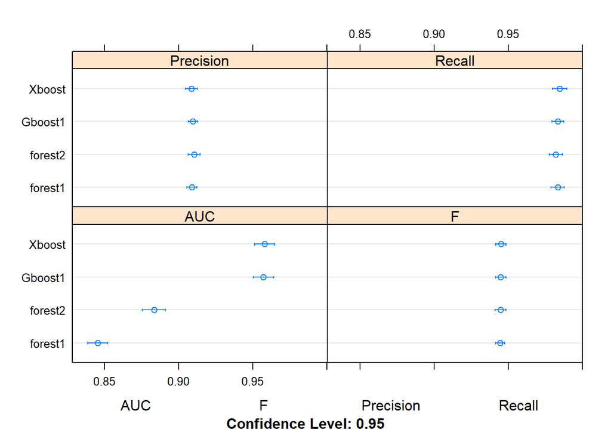

```r
dotplot(results)
```

Aussi, on observe que les modèles les plus performants sont les deux types de gradient boosting, qui bien que plus long à entrainer que les randoms forest du fait de leurs plus nombreux paramètres, ils semblent mieux performer une fois le tuning des paramètres efféctué.

## Dépot

Nous n’avons pu soumettre que les données traitées par la random forest avec mtry= 5, le meilleur score obtenu sur Kaggle est de 91.8.

```r
test=read.csv("test.csv")
test=preProcessing(test)
colnames(test)
```

```
##  [1] "age"            "job"            "marital"        "education"
##  [5] "default"        "housing"        "loan"           "contact"
##  [9] "month"          "day_of_week"    "duration"       "campaign"
## [13] "pdays"          "previous"       "poutcome"       "emp.var.rate"
## [17] "cons.price.idx" "cons.conf.idx"  "euribor3m"      "nr.employed"
```

```r
predictions=predict(fit.forest2,newdata = test)
print(predictions)
```

[output not shown]

[output cut: 42 more lines]

```r
to_be_submitted = data.frame(id=rownames(test), y=predictions)
write.csv(to_be_submitted , file = "to_be_submitted.csv", row.names = F)
```

[1] *An Up-to-Date Comparison of State-of-the-Art Classification Algorithms*, Zang et al, 2017